# Preprocesamiento de Datos.

Facultad de Estadística e Informática UV

Irán Apolinar Peredo Cortes

El presente documento forma parte del Anexo 2 del trabajo recepcional **“Visualización de datos implementada con R y Python”**.

## Preprocesamiento de datos

La librería `dplyr` permite la manipulación de bases de datos con funciones `select`, `filter`, `mutate`, `recode`, `case_when` que permite la facil modificación de la base de datos previo la realización de la visualización de datos.

```r
#install.packages("tidyverse")
library(tidyverse)
```

Utilizaremos la base de datos sobre mortalidad materna la cual muestra datos del banco mundial y de la OMS entre el 2015 y 2020.

```r
materna <- read_csv("https://raw.githubusercontent.com/IranNash/visualizacionDeDatos/main/materna.csv")
head(materna)
```

| Country | mortality | adolescent | gini | tertiary | gdp_educ | idh | gdpp | aborto |
| --- | --- | --- | --- | --- | --- | --- | --- | --- |
| Afghanistan | 396 | 68.957 | NA | 9.99214 | 3.92675 | 0.4959595 | 1734.723 | 0 |
| Albania | 29 | 19.642 | 29.0 | 56.97501 | 3.95464 | 0.7914059 | 12306.262 | 1 |
| Algeria | 140 | 10.071 | 27.6 | 47.72093 | NA | 0.7589777 | 13886.134 | 0 |
| Angola | 477 | 150.526 | 42.7 | 9.43492 | 3.42100 | 0.5744878 | 5725.327 | 1 |
| Argentina | 52 | 62.782 | 40.6 | 89.08190 | 5.57218 | 0.8300958 | 18282.094 | 0 |
| Armenia | 25 | 21.490 | 33.6 | 52.24242 | 2.75812 | 0.7600109 | 9177.744 | 1 |

### Filtros

Una forma simple de realizar el filtro es directamente escribiendo la instrucción `filter`, agregando la base de datos y el filtro elegido. Podemos estar interesados en encontrar solo los valores cuando mortality es mayor a 100.

```r
filter(materna, mortality > 100)
```

| Country | mortality | adolescent | gini | tertiary | gdp_educ | idh | gdpp | aborto |
| --- | --- | --- | --- | --- | --- | --- | --- | --- |
| Afghanistan | 396 | 68.957 | NA | 9.99214 | 3.92675 | 0.4959595 | 1734.7232 | 0 |
| Algeria | 140 | 10.071 | 27.6 | 47.72093 | NA | 0.7589777 | 13886.1337 | 0 |
| Angola | 477 | 150.526 | 42.7 | 9.43492 | 3.42100 | 0.5744878 | 5725.3272 | 1 |
| Bangladesh | 176 | 82.962 | 32.4 | 17.61572 | 1.53554 | 0.6136793 | 3879.1615 | 0 |
| Benin | 405 | 86.096 | 47.8 | 12.94940 | 3.99469 | 0.5198342 | 2151.5432 | 0 |
| Bhutan | 148 | 20.184 | 37.4 | 10.51472 | 7.05049 | 0.6172988 | 9347.8265 | 0 |
| Bolivia | 206 | 64.900 | 44.0 | NA | 7.28535 | 0.7028424 | 6986.0465 | 0 |
| Botswana | 129 | 46.061 | 53.3 | 23.00962 | NA | 0.7277871 | 16518.2357 | 0 |
| Burkina Faso | 371 | 104.329 | 35.3 | 6.00336 | 4.16607 | 0.4335470 | 1755.5929 | 0 |
| Burundi | 712 | 55.590 | 38.6 | 6.16473 | 4.34407 | 0.4228816 | 660.2656 | 0 |

[output cut: 59 more lines]

Una forma más eficiente es utilizar la función `%>%` que permite concatenar instrucciones.

```r
materna %>% filter(mortality > 100)
```

| Country | mortality | adolescent | gini | tertiary | gdp_educ | idh | gdpp | aborto |
| --- | --- | --- | --- | --- | --- | --- | --- | --- |
| Afghanistan | 396 | 68.957 | NA | 9.99214 | 3.92675 | 0.4959595 | 1734.7232 | 0 |
| Algeria | 140 | 10.071 | 27.6 | 47.72093 | NA | 0.7589777 | 13886.1337 | 0 |
| Angola | 477 | 150.526 | 42.7 | 9.43492 | 3.42100 | 0.5744878 | 5725.3272 | 1 |
| Bangladesh | 176 | 82.962 | 32.4 | 17.61572 | 1.53554 | 0.6136793 | 3879.1615 | 0 |
| Benin | 405 | 86.096 | 47.8 | 12.94940 | 3.99469 | 0.5198342 | 2151.5432 | 0 |
| Bhutan | 148 | 20.184 | 37.4 | 10.51472 | 7.05049 | 0.6172988 | 9347.8265 | 0 |
| Bolivia | 206 | 64.900 | 44.0 | NA | 7.28535 | 0.7028424 | 6986.0465 | 0 |
| Botswana | 129 | 46.061 | 53.3 | 23.00962 | NA | 0.7277871 | 16518.2357 | 0 |
| Burkina Faso | 371 | 104.329 | 35.3 | 6.00336 | 4.16607 | 0.4335470 | 1755.5929 | 0 |
| Burundi | 712 | 55.590 | 38.6 | 6.16473 | 4.34407 | 0.4228816 | 660.2656 | 0 |

[output cut: 59 more lines]

Podemos utilizar más de un filtro agregando la instrucción `&` entre filtros.

```r
materna %>% filter(mortality > 100 & gini < 40)
```

| Country | mortality | adolescent | gini | tertiary | gdp_educ | idh | gdpp | aborto |
| --- | --- | --- | --- | --- | --- | --- | --- | --- |
| Algeria | 140 | 10.071 | 27.6 | 47.72093 | NA | 0.7589777 | 13886.1337 | 0 |
| Bangladesh | 176 | 82.962 | 32.4 | 17.61572 | 1.53554 | 0.6136793 | 3879.1615 | 0 |
| Bhutan | 148 | 20.184 | 37.4 | 10.51472 | 7.05049 | 0.6172988 | 9347.8265 | 0 |
| Burkina Faso | 371 | 104.329 | 35.3 | 6.00336 | 4.16607 | 0.4335470 | 1755.5929 | 0 |
| Burundi | 712 | 55.590 | 38.6 | 6.16473 | 4.34407 | 0.4228816 | 660.2656 | 0 |
| Ethiopia | 353 | 66.727 | 39.1 | 8.12231 | 4.73792 | 0.4698496 | 1794.2908 | 0 |
| Gabon | 291 | 96.227 | 38.0 | NA | 2.66668 | 0.7016253 | 15922.1933 | 0 |
| Gambia | 706 | 78.185 | 35.9 | NA | 3.08513 | 0.4657249 | 1516.6900 | 0 |
| Guinea | 679 | 135.294 | 33.7 | 11.25905 | 2.21200 | 0.4655150 | 2337.9515 | 0 |
| India | 174 | 13.177 | 35.7 | 27.54031 | 3.84467 | 0.6469011 | 6899.2139 | 0 |

[output cut: 18 more lines]

Ahora apliquemos tres filtros.

```r
materna %>% filter(mortality > 100 & gini < 40 & adolescent > 80)
```

| Country | mortality | adolescent | gini | tertiary | gdp_educ | idh | gdpp | aborto |
| --- | --- | --- | --- | --- | --- | --- | --- | --- |
| Bangladesh | 176 | 82.962 | 32.4 | 17.61572 | 1.53554 | 0.6136793 | 3879.1615 | 0 |
| Burkina Faso | 371 | 104.329 | 35.3 | 6.00336 | 4.16607 | 0.4335470 | 1755.5929 | 0 |
| Gabon | 291 | 96.227 | 38.0 | NA | 2.66668 | 0.7016253 | 15922.1933 | 0 |
| Guinea | 679 | 135.294 | 33.7 | 11.25905 | 2.21200 | 0.4655150 | 2337.9515 | 0 |
| Liberia | 725 | 135.962 | 35.3 | NA | 3.82627 | 0.4647203 | 1161.1779 | 0 |
| Mali | 587 | 169.127 | 33.0 | 5.48990 | 3.09071 | 0.4272062 | 2055.6229 | 0 |
| Niger | 553 | 186.538 | 34.3 | 4.01831 | 3.54273 | 0.3765911 | 931.9875 | 0 |
| Sao Tome and Principe | 156 | 94.610 | 30.8 | 13.05538 | 4.85713 | 0.6085562 | 3033.3930 | 0 |
| Sierra Leone | 1360 | 112.828 | 34.0 | NA | 4.63672 | 0.4384653 | 1425.3416 | 0 |
| Tanzania | 398 | 118.385 | 37.8 | 3.91998 | 3.48143 | 0.5283026 | 2809.0690 | 0 |

### Seleccionar

Una alternativa muy útil es la función `select` que permite seleccionar solo las variales de interés.

```r
materna %>% select(mortality, gdpp, adolescent)
```

| mortality | gdpp | adolescent |
| --- | --- | --- |
| 396 | 1734.7232 | 68.957 |
| 29 | 12306.2622 | 19.642 |
| 140 | 13886.1337 | 10.071 |
| 477 | 5725.3272 | 150.526 |
| 52 | 18282.0939 | 62.782 |
| 25 | 9177.7442 | 21.490 |
| 6 | 45439.3072 | 11.715 |
| 4 | 46473.2572 | 7.340 |
| 25 | 16010.9890 | 55.838 |
| 15 | 41973.3020 | 13.368 |

[output cut: 163 more lines]

### Concatenar instrucciones

Para concatenar instrucciones podemos seguir utilizando el operador `%>%`. en este caso primero hacemos el filtro y luego concatenamos.

```r
materna %>% filter( mortality > 100 & adolescent > 30) %>%
  select(mortality, idh, aborto)
```

| mortality | idh | aborto |
| --- | --- | --- |
| 396 | 0.4959595 | 0 |
| 477 | 0.5744878 | 1 |
| 176 | 0.6136793 | 0 |
| 405 | 0.5198342 | 0 |
| 206 | 0.7028424 | 0 |
| 129 | 0.7277871 | 0 |
| 371 | 0.4335470 | 0 |
| 712 | 0.4228816 | 0 |
| 161 | 0.5814850 | 1 |
| 596 | 0.5627253 | 0 |

[output cut: 53 more lines]

Otro ejemplo podría ser:

```r
materna %>% filter( mortality >= 100 & adolescent >= 30) %>%
  select(mortality, idh, aborto) %>% filter(aborto == 0)
```

| mortality | idh | aborto |
| --- | --- | --- |
| 396 | 0.4959595 | 0 |
| 176 | 0.6136793 | 0 |
| 405 | 0.5198342 | 0 |
| 206 | 0.7028424 | 0 |
| 129 | 0.7277871 | 0 |
| 371 | 0.4335470 | 0 |
| 712 | 0.4228816 | 0 |
| 596 | 0.5627253 | 0 |
| 882 | 0.3806621 | 0 |
| 856 | 0.4011760 | 0 |

[output cut: 49 more lines]

```r
#En los filtros debe ser >= y nunca =>, para confirmar una igualdad debe ser ==
```

### Creación de variables

Para crear variables utilizamos `mutate`, en este caso nos interesa crear el logaritmo del `gdpp`. Una vez creada solo seleccionamos las variables de interés (concatenando).

```r
materna %>% mutate(log_gdpp = log(gdpp)) %>% select(gdpp, log_gdpp)
```

| gdpp | log_gdpp |
| --- | --- |
| 1734.7232 | 7.458603 |
| 12306.2622 | 9.417864 |
| 13886.1337 | 9.538646 |
| 5725.3272 | 8.652655 |
| 18282.0939 | 9.813677 |
| 9177.7442 | 9.124537 |
| 45439.3072 | 10.724133 |
| 46473.2572 | 10.746632 |
| 16010.9890 | 9.681031 |
| 41973.3020 | 10.644789 |

[output cut: 163 more lines]

Otro ejemplo podría ser:

```r
materna %>% mutate(gini2 = gini/100) %>%  select(gini, gini2)
```

| gini | gini2 |
| --- | --- |
| NA | NA |
| 29.0 | 0.290 |
| 27.6 | 0.276 |
| 42.7 | 0.427 |
| 40.6 | 0.406 |
| 33.6 | 0.336 |
| 35.8 | 0.358 |
| 30.5 | 0.305 |
| NA | NA |
| NA | NA |

[output cut: 163 more lines]

Al crear una nueva variable podemos segmentar la variable en casos de interés. Esto es muy común, segmentar una variable cuantitativa para crear estratos. En este caso segmentaremos la variale IDH y concatenamos una selección.

```r
materna %>% mutate(desarrollo = case_when(
  idh <= 0.33 ~ "Bajo",
  idh <= 0.66 ~ "Medio",
  idh > 0.66 ~ "Alto" )) %>% select(idh, desarrollo)
```

| idh | desarrollo |
| --- | --- |
| 0.4959595 | Medio |
| 0.7914059 | Alto |
| 0.7589777 | Alto |
| 0.5744878 | Medio |
| 0.8300958 | Alto |
| 0.7600109 | Alto |
| 0.9383786 | Alto |
| 0.9138085 | Alto |
| 0.7538687 | Alto |
| 0.8377702 | Alto |

[output cut: 163 more lines]

Al mirar el histograma podemos pensar que una forma más eficiente para hacer la segmentación es utilizando cuantiles.

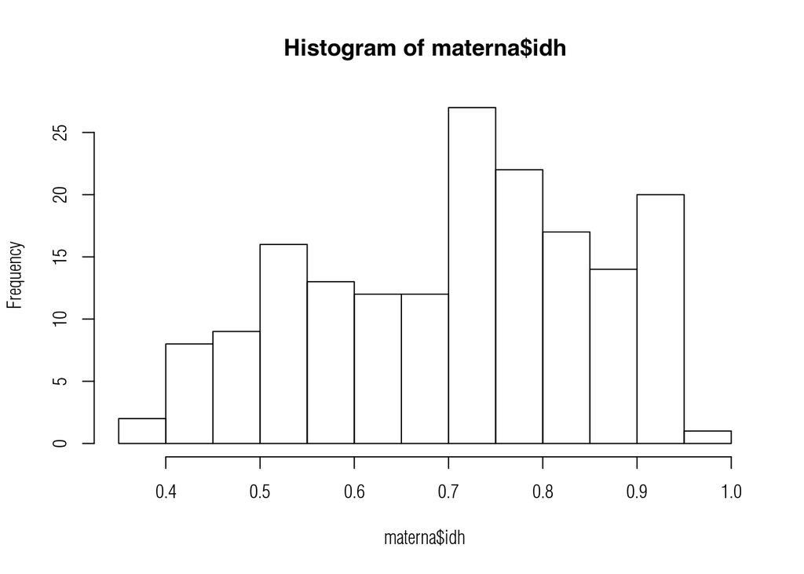

```r
hist(materna$idh)
```

Con `quantile` generamos cuantiles, en este caso nos interesa el primer y tercer cuartil, es decir el 25% y 75% de los datos.

```r
quantile(materna$idh)
```

```
##        0%       25%       50%       75%      100%
## 0.3765911 0.5842522 0.7236929 0.8240379 0.9536883
```

```r
quantile(materna$idh, probs = 0.25, na.rm = TRUE)
```

```
##       25%
## 0.5842522
```

```r
q1 = as.numeric(quantile(materna$idh, probs = 0.25, na.rm = TRUE))
```

```r
q3 = as.numeric(quantile(materna$idh, probs = 0.75, na.rm = TRUE))
```

Una vez calculados los cuartiles podemos volver a hacer la segmentación.

```r
materna %>% mutate(desarrollo = case_when(
  idh <= q1 ~ "Bajo",
  idh <= q3 ~ "Medio",
  idh > q3 ~ "Alto" )) %>% select(idh, desarrollo)
```

| idh | desarrollo |
| --- | --- |
| 0.4959595 | Bajo |
| 0.7914059 | Medio |
| 0.7589777 | Medio |
| 0.5744878 | Bajo |
| 0.8300958 | Alto |
| 0.7600109 | Medio |
| 0.9383786 | Alto |
| 0.9138085 | Alto |
| 0.7538687 | Medio |
| 0.8377702 | Alto |

[output cut: 163 more lines]

### Recodificacion

La recodificación se realiza con `recode`. Dentro de `mutate` recodificamos la variable, igualamos cada valor de la base de datos a un nuevo valor, en este ejemplo recodificamos la variable `aborto`.

```r
materna %>%
  mutate(aborto2 = recode(aborto, "1" = "Con aborto", "0" = "Sin aborto")) %>%
  select(aborto, aborto2)
```

| aborto | aborto2 |
| --- | --- |
| 0 | Sin aborto |
| 1 | Con aborto |
| 0 | Sin aborto |
| 1 | Con aborto |
| 0 | Sin aborto |
| 1 | Con aborto |
| 1 | Con aborto |
| 1 | Con aborto |
| 1 | Con aborto |
| 0 | Sin aborto |

[output cut: 163 more lines]

### Manejo de NA

Los NA tiene varios tratamientos de codificación. Primero identifiquemos los NA de alguna variable, en este caso de la variable `gini`.

```r
is.na(materna$gini)
```

```
##   [1]  TRUE FALSE FALSE FALSE FALSE FALSE FALSE FALSE  TRUE  TRUE FALSE FALSE
##  [13] FALSE  TRUE FALSE FALSE FALSE FALSE FALSE FALSE  TRUE FALSE FALSE FALSE
##  [25] FALSE  TRUE FALSE FALSE FALSE FALSE FALSE FALSE FALSE FALSE FALSE FALSE
##  [37] FALSE FALSE FALSE FALSE FALSE FALSE FALSE FALSE FALSE FALSE FALSE  TRUE
##  [49]  TRUE FALSE FALSE FALSE FALSE FALSE FALSE FALSE FALSE FALSE FALSE FALSE
##  [61] FALSE  TRUE FALSE FALSE FALSE  TRUE FALSE FALSE FALSE FALSE FALSE FALSE
##  [73] FALSE FALSE FALSE FALSE FALSE  TRUE FALSE FALSE FALSE FALSE  TRUE FALSE
##  [85]  TRUE FALSE FALSE FALSE FALSE FALSE FALSE  TRUE FALSE FALSE FALSE FALSE
##  [97] FALSE FALSE FALSE FALSE FALSE FALSE FALSE FALSE FALSE FALSE FALSE FALSE
## [109] FALSE FALSE FALSE FALSE FALSE FALSE FALSE FALSE FALSE FALSE  TRUE FALSE
## [121] FALSE FALSE FALSE FALSE FALSE FALSE FALSE FALSE  TRUE FALSE FALSE FALSE
## [133] FALSE  TRUE FALSE FALSE  TRUE FALSE FALSE FALSE FALSE FALSE FALSE FALSE
## [145] FALSE FALSE FALSE FALSE  TRUE FALSE FALSE  TRUE FALSE FALSE FALSE FALSE
## [157] FALSE FALSE FALSE FALSE  TRUE FALSE FALSE FALSE FALSE FALSE  TRUE FALSE
## [169]  TRUE FALSE FALSE FALSE FALSE
```

Como se observa, cuando la opción marca `TRUE` implica que es un valor con NA. Una forma de recodificar la variable es asignando un caracter cada vez que aparezca un NA. Esto se puede realizar con `ifelse` y dentro de la condición se introduce el `is.na()` ya que un requisito para usar `ìfelse` es que el resultado sea una condición.

```r
materna %>% select(gini) %>% mutate(gini = ifelse(is.na(gini), "sin datos", gini))
```

| gini |
| --- |
| sin datos |
| 29 |
| 27.6 |
| 42.7 |
| 40.6 |
| 33.6 |
| 35.8 |
| 30.5 |
| sin datos |
| sin datos |

[output cut: 163 more lines]

Para pasar de un caracter a un NA primero guardamos la variable generada en un data frame auxiliar.

```r
aux <- materna %>% select(gini) %>% mutate(gini = ifelse(is.na(gini), "sin datos", gini))
head(aux)
```

| gini |
| --- |
| sin datos |
| 29 |
| 27.6 |
| 42.7 |
| 40.6 |
| 33.6 |

Una vez guardada con la instrucción `na_if` colocamos la variable y el tipo de codificación que deseamos pasar a NA.

```r
aux %>% mutate(gini = na_if(gini, "sin datos"))
```

| gini |
| --- |
| NA |
| 29 |
| 27.6 |
| 42.7 |
| 40.6 |
| 33.6 |
| 35.8 |
| 30.5 |
| NA |
| NA |

[output cut: 163 more lines]

Para eliminar todos los datos faltantes solo concatamos la instrucción `na.omit`.

```r
materna <- materna %>% na.omit()
View(materna)
```

### Agrupación de datos

Para realizar la agrupación de variables guardaremos tanto la variable categórica y la recodificación de la variable `aborto`.

```r
materna <-materna %>% mutate(desarrollo = case_when(
  idh <= q1 ~ "Bajo",
  idh <= q3 ~ "Medio",
  idh > q3 ~ "Alto" )) %>%
  mutate(aborto = recode(aborto, "1" = "Con aborto", "0" = "Sin aborto"))
```

Para realizar agrupaciones utilizamos `group_by` sobre la variable seleccionada. Esta variable suele ser una categoría o una variable de tipo caracter, sin embargo puede ser aplicada a variables enteras. Como tal esta instrucción no genera una salida. Una vez agrupado concatenamos una instrucción como `count` para contar los objetos agrupados.

```r
materna %>% group_by(aborto) %>% count()
```

| aborto | n |
| --- | --- |
| Con aborto | 43 |
| Sin aborto | 73 |

O con `summarise` es posible calcular estadísticas de interés por cada grupo.

```r
materna %>% group_by(aborto) %>% summarise( media = mean(mortality))
```

| aborto | media |
| --- | --- |
| Con aborto | 28.02326 |
| Sin aborto | 207.57534 |

Podemos fijar más de una estadística por grupo.

```r
materna %>% group_by(aborto) %>% summarise(media = mean(mortality),
                                           sd = sd(mortality),
                                           minimo = min(mortality),
                                           maximo = max(mortality))
```

| aborto | media | sd | minimo | maximo |
| --- | --- | --- | --- | --- |
| Con aborto | 28.02326 | 73.61272 | 1 | 477 |
| Sin aborto | 207.57534 | 218.24120 | 3 | 856 |

Aquí otro ejemplo.

```r
materna %>% group_by(desarrollo) %>% summarise(media = mean(mortality),
                                           sd = sd(mortality),
                                           minimo = min(mortality),
                                           maximo = max(mortality))
```

| desarrollo | media | sd | minimo | maximo |
| --- | --- | --- | --- | --- |
| Alto | 8.763158 | 8.445162 | 1 | 52 |
| Bajo | 453.115385 | 166.685651 | 178 | 856 |
| Medio | 81.615385 | 94.075930 | 4 | 442 |

### Reordenar factores

En R, en el momento de visualizar una variable categórica, los factores suelen estar ordenados en orden alfabética, lo cual en la mayoría de los casos es incorrecto. Realicemos un gráfico simple para ilustrar este problema.

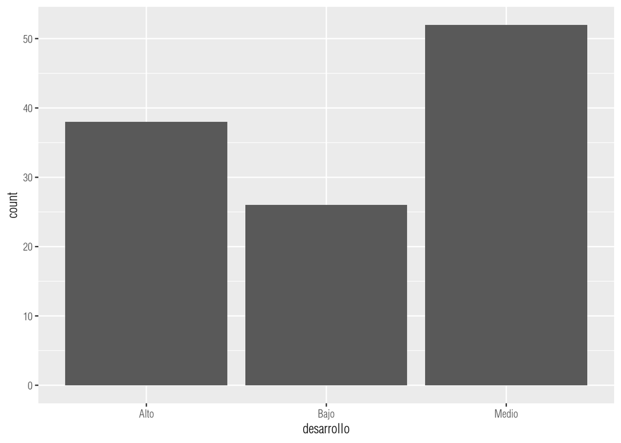

```r
ggplot2::ggplot(data = materna, aes(x = desarrollo)) +
  geom_bar()
```

Como se observa los factores están en orden alfabético. Para reordenar el factor utilizamos la instrucción `factor` y `levels`, donde se especifica la orden del factor.

```r
materna <- materna %>% mutate(desarrollo = factor(desarrollo, levels = c("Bajo", "Medio", "Alto")))
```

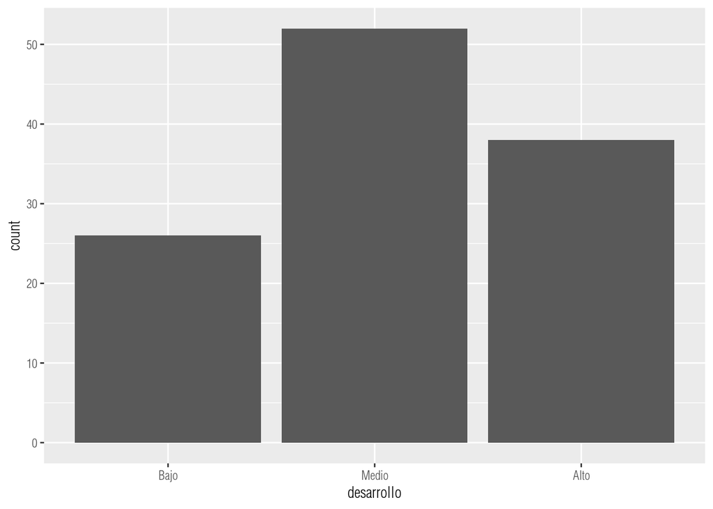

```r
ggplot2::ggplot(data = materna, aes(x = desarrollo)) +
  geom_bar()
```

### Alargamiento- compactación

Dentro de la libreŕia `tidyr` existen funciones para alargar o compactar una base de datos, esto puede ser conveniete para algunos tipos de gráfico en R. con la función `spread` permite alargar una base de datos. En `key` se asigna una categoría existente y en `value` una variable cuantitativa de interes. Para este ejemplo guardemos esto en una base auxiliar.

```r
library(tidyr)
aux = materna  %>% spread(key = aborto, value = mortality)
#que variables contiene
names(aux)
```

```
##  [1] "Country"    "adolescent" "gini"       "tertiary"   "gdp_educ"
##  [6] "idh"        "gdpp"       "desarrollo" "Con aborto" "Sin aborto"
```

Como se observa ambas categorías que se encuentran en `aborto`, es decir `Con aborto` y `Sin aborto` ahora son columnas de la base de datos. Ahora mostramos las variables generadas.

```r
aux %>% select("Con aborto", "Sin aborto")
```

| Con aborto | Sin aborto |
| --- | --- |
| 29 | NA |
| 477 | NA |
| NA | 52 |
| 25 | NA |
| 6 | NA |
| 4 | NA |
| NA | 176 |
| 4 | NA |
| 7 | NA |
| NA | 405 |

[output cut: 106 more lines]

Con la función `gather` hacemos la función inversa. Seleccionamos una nueva variable `key` y una nueva variable `value`, de igual manera se agregan las variables a compactar.

```r
#key = nombre del factor, "value = la nueva variable cuantitativa"
aux %>% gather(key = "aborto2", value = "mortalidad", "Con aborto", "Sin aborto")
```

| Country | adolescent | gini | tertiary | gdp_educ | idh | gdpp | desarrollo | aborto2 | mortalidad |
| --- | --- | --- | --- | --- | --- | --- | --- | --- | --- |
| Albania | 19.642 | 29.0 | 56.97501 | 3.95464 | 0.7914059 | 12306.2622 | Medio | Con aborto | 29 |
| Angola | 150.526 | 42.7 | 9.43492 | 3.42100 | 0.5744878 | 5725.3272 | Bajo | Con aborto | 477 |
| Argentina | 62.782 | 40.6 | 89.08190 | 5.57218 | 0.8300958 | 18282.0939 | Alto | Con aborto | NA |
| Armenia | 21.490 | 33.6 | 52.24242 | 2.75812 | 0.7600109 | 9177.7442 | Medio | Con aborto | 25 |
| Australia | 11.715 | 35.8 | 113.76884 | 5.32175 | 0.9383786 | 45439.3072 | Alto | Con aborto | 6 |
| Austria | 7.340 | 30.5 | 86.31161 | 5.45304 | 0.9138085 | 46473.2572 | Alto | Con aborto | 4 |
| Bangladesh | 82.962 | 32.4 | 17.61572 | 1.53554 | 0.6136793 | 3879.1615 | Medio | Con aborto | NA |
| Belarus | 14.507 | 25.4 | 86.68179 | 4.82003 | 0.8170680 | 17741.8622 | Medio | Con aborto | 4 |
| Belgium | 4.651 | 27.7 | 75.89064 | 6.55238 | 0.9188412 | 43217.9522 | Alto | Con aborto | 7 |
| Benin | 86.096 | 47.8 | 12.94940 | 3.99469 | 0.5198342 | 2151.5432 | Bajo | Con aborto | NA |

[output cut: 222 more lines]

```r
names(aux) %>% names()
```

Otra forma de hacerlo es dando la secuencia de columnas sin especificar los nombres de las columnas.

```r
#key = nombre del factor, "value = la nueva variable cuantitativa"
aux %>%
  gather(key = "aborto2", value = "mortalidad", 9:10) %>% names()
```

```
##  [1] "Country"    "adolescent" "gini"       "tertiary"   "gdp_educ"
##  [6] "idh"        "gdpp"       "desarrollo" "aborto2"    "mortalidad"
```

```r
aux %>%
  gather(key = "aborto2", value = "mortalidad", 9:10) %>%
  select(Country, mortalidad, aborto2)
```

| Country | mortalidad | aborto2 |
| --- | --- | --- |
| Albania | 29 | Con aborto |
| Angola | 477 | Con aborto |
| Argentina | NA | Con aborto |
| Armenia | 25 | Con aborto |
| Australia | 6 | Con aborto |
| Austria | 4 | Con aborto |
| Bangladesh | NA | Con aborto |
| Belarus | 4 | Con aborto |
| Belgium | 7 | Con aborto |
| Benin | NA | Con aborto |

[output cut: 222 more lines]

```r
materna %>% select(Country, mortality, aborto)
```

| Country | mortality | aborto |
| --- | --- | --- |
| Albania | 29 | Con aborto |
| Angola | 477 | Con aborto |
| Argentina | 52 | Sin aborto |
| Armenia | 25 | Con aborto |
| Australia | 6 | Con aborto |
| Austria | 4 | Con aborto |
| Bangladesh | 176 | Sin aborto |
| Belarus | 4 | Con aborto |
| Belgium | 7 | Con aborto |
| Benin | 405 | Sin aborto |

[output cut: 106 more lines]

```r
aux %>%
  gather(key = "aborto2", value = "mortalidad", 9:10) %>%
  select(Country, mortalidad, aborto2) %>% na.omit()
```

| Country | mortalidad | aborto2 |
| --- | --- | --- |
| Albania | 29 | Con aborto |
| Angola | 477 | Con aborto |
| Armenia | 25 | Con aborto |
| Australia | 6 | Con aborto |
| Austria | 4 | Con aborto |
| Belarus | 4 | Con aborto |
| Belgium | 7 | Con aborto |
| Bulgaria | 11 | Con aborto |
| Canada | 7 | Con aborto |
| China | 27 | Con aborto |

[output cut: 106 more lines]

```r
aux %>%
  gather(key = "aborto2", value = "mortalidad", 9:10) %>%
  select(Country, mortalidad, aborto2) %>% na.omit() %>%
  filter(Country == "Argentina")
```

| Country | mortalidad | aborto2 |
| --- | --- | --- |
| Argentina | 52 | Sin aborto |